# NEON variable associations

Clay Morrow

2025-05-02

# 1 Introduction

To enhance readability, `tidyverse` functions and syntax will be used often throughout this document.

# 2 Setup

This document was last rendered: 2025-05-19

First, we load the R packages that we’ll use and point to the directory in which NEON data are saved. Data objects will be loaded from here as needed throughout the rest of this document.

```r
library(tidyverse)
library(lubridate) # manage dates
library(lemon) # ggplot extension
```

```r
# path to NEON data directory
neon_data_dir = "../neon-data-curation/data/eight_sites"

# check that the directory exists
stopifnot(dir.exists(neon_data_dir))
```

```r
my_token <- readLines(
  "../neon-data-curation/docs/NEON-API-token-morrow5.txt"
)
```

```r
NEON_sites <- read.csv("data/raw-data/NEON-SiteMap-Table.csv") |>
  tibble()
```

```r
trap_locations <- readRDS(
  file.path(
    "../neon-data-curation/data/eight_sites",
    "location_data/small-mammal-trap-locations.rds"
  )
)
```

# 3 Small mammal data

The small mammal data product object is a list of multiple data and metadata tables. The `$readme*` object describes the product and `$variables*` table describes the different fields of each table. The primary table we want is called `mam_pertrapnight`, which has one row for each capture (or lack thereof) per trap per night. We’ll simply the name of this dataset to `mammals` from here on out.

```r
# load the small mammal trapping data products
mammal_prods <- readRDS(file.path(neon_data_dir, "mammal-trap-data.rds"))

# Extract a tibble of the "mammals per trap night" data object
mammals <- mammal_prods$mam_pertrapnight |> tibble()

# number of observations in the mammal table
n_mammals <- nrow(mammals)
```

The field descriptions of the `mammals` data are contained within the `$variables*` object:

```r
# Get a variable lookup metadata table, for our mammal data
mammal_var_lookup <- mammal_prods$variables_10072 |>
  filter(table == "mam_pertrapnight") |>
  tibble()

# Print the variable lookup table
mammal_var_lookup |> select(fieldName, units, description)
```

```
## # A tibble: 70 × 3
##    fieldName       units         description
##    <chr>           <chr>         <chr>
##  1 uid             <NA>          Unique ID within NEON database; an identifier …
##  2 nightuid        <NA>          Unique ID of associated record in perplotnight…
##  3 namedLocation   <NA>          Name of the measurement location in the NEON d…
##  4 domainID        <NA>          Unique identifier of the NEON domain
##  5 siteID          <NA>          NEON site code
##  6 plotID          <NA>          Plot identifier (NEON site code_XXX)
##  7 trapCoordinate  <NA>          Relative coordinate of the trap within the giv…
##  8 plotType        <NA>          NEON plot type in which sampling occurred: tow…
##  9 nlcdClass       <NA>          National Land Cover Database Vegetation Type N…
## 10 decimalLatitude decimalDegree The geographic latitude (in decimal degrees, W…
## # ℹ 60 more rows
```

We will next clean up `mammals` a bit to make it easier to use. Notably, many of the columns that we probably won’t use get collapsed into a single list-column (via `tibble`). This allows removal of some clutter without losing any data.

```r
# collapse some variables that we are unlikely to use
mammals <- mammals |>
  arrange(collectDate, plotID, nightuid, trapCoordinate, uid) |>
  ungroup() |>
  mutate(cap_id_num = row_number()) |> # create a row ID to simplify uid.
  relocate(cap_id_num, .before = 1) |>
  group_by(uid) |>
  nest(
    other_mammal_vars = c(
      namedLocation, domainID, plotType, nlcdClass, geodeticDatum,
      coordinateUncertainty, elevationUncertainty, trapType, individualCode,
      taxonRank:nativeStatusCode, replacedTag, frozenSamplePrepMethod,
      bloodSampleID, bloodSampleMethod, fecalSampleID, fecalSampleCondition,
      earSampleID, hairSampleID, hairSampleContents, voucherSampleID:release
    )
  ) |> ungroup()

# ensure n hasn't changed - this check will be repeated periodically
stopifnot(nrow(mammals) == n_mammals)
```

We’ll also get some extra information about year, month, day, and Julian day (`DOY`: day-of-year). We’re going to hold off on formatting the actual date columns (`collectDate` and `endDate`) for now because they may be used for joining with other data tables.

```r
# add new time variables
mammals <- mammals |>
  mutate(
    year = year(collectDate),
    month = month(collectDate),
    day = day(collectDate),
    DOY = yday(collectDate)
  ) |>
  relocate(year, month, day, DOY, .before = collectDate)
```

And we’ll also refactor some of the categorical variables to be more useful in modeling

```r
# refactor the tick info
mammals <- mammals |>
  mutate(
    tickNumber = if_else(
      larvalTicksAttached != "Y" &
        nymphalTicksAttached != "Y" &
        adultTicksAttached != "Y" &
        tickNumber != "No count performed", true = "0", false = tickNumber
    ),
    tickNumber = factor(
      tickNumber, levels = c("0", "1-5", "6-20", ">20"), ordered = TRUE
    ),
    nymphalTicksAttached = factor(
      nymphalTicksAttached, levels = c("N", "Y"), ordered = TRUE
    ),
    larvalTicksAttached = factor(
      larvalTicksAttached, levels = c("N", "Y"), ordered = TRUE
    ),
    adultTicksAttached = factor(
      adultTicksAttached, levels = c("N", "Y"), ordered = TRUE
    )
  )

mammals$tickNumber |> table()
```

```
##
##    0  1-5 6-20  >20
##   14 3600  579   34
```

# 4 Pathogens

### 4.0.1 tick-borne

Next, we’ll load the tick-borne pathogens neon data product. As with the small mammal product, there are multiple tables contained within this product. The main data is stored in `rpt2_pathogentesting`, which we will rename to `pathogens`.

```r
# read the NEON tick-borne pathogen product object
pathogen_prods <- readRDS(
  file.path(neon_data_dir, "rodent-tickborne-pathogen-status.rds")
)

# extract the main pathogen testing table
pathogens <- pathogen_prods$rpt2_pathogentesting |> tibble()

n_pathogens <- length(unique(pathogens$testPathogenName))

# get a variable lookup metadata table for this dataset
pathogen_var_lookup <- pathogen_prods$variables_10064 |>
  filter(table == "rpt2_pathogentesting") |> tibble()

# view the lookup table
pathogen_var_lookup |> select(fieldName, units, description)
```

```
## # A tibble: 25 × 3
##    fieldName      units description
##    <chr>          <lgl> <chr>
##  1 uid            NA    Unique ID within NEON database; an identifier for the r…
##  2 namedLocation  NA    Name of the measurement location in the NEON database
##  3 domainID       NA    Unique identifier of the NEON domain
##  4 siteID         NA    NEON site code
##  5 laboratoryName NA    Name of the laboratory or facility that is processing t…
##  6 plotID         NA    Plot identifier (NEON site code_XXX)
##  7 collectDate    NA    Date of the collection event
##  8 testedDate     NA    Date test was conducted
##  9 testedBy       NA    An identifier for the technician who tested the sample
## 10 sampleID       NA    Identifier for sample
## # ℹ 15 more rows
```

The `pathogens` data has 1 row per test (ear and/or blood) per pathogen (18 possible) per individual. Linking these samples to an individual capture (`mammals$uid`) requires matching the `sampleCode` variable with either `bloodSampleBarcode` or `earSampleBarcode` from the `mammal` table, depending on whether `sampleID` ends with “.E” (ear) or “.B” (blood).

```r
# add in an indicator of "blood" or "ear" for sampling and matched mammal row
pathogens <- pathogens |>
  mutate(
    year = year(.data$collectDate),
    sample_method = dplyr::case_when(
      grepl(".*\\.E$", sampleID) ~ "ear",
      grepl(".*\\.B$", sampleID) ~ "blood",
      .default = NA
    ),
    matched_mammal_index = dplyr::case_when(
      sample_method == "ear" ~ match(sampleCode, mammals$earSampleBarcode),
      sample_method == "blood" ~ match(sampleCode, mammals$bloodSampleBarcode),
      .default = NA
    ),
    mammal_uid = mammals$uid[.data$matched_mammal_index],
  )

# check that all samples had a match (ear subset)
pathogens |> filter(sample_method == "ear") |>
  pull(.data$sampleCode) %in% mammals$earSampleBarcode |> all() |>
  stopifnot()

# (blood subset)
pathogens |> filter(sample_method == "blood") |>
  pull(.data$sampleCode) %in% mammals$bloodSampleBarcode |> all() |>
  stopifnot()
```

The `pathogen` data is then transformed such that there is one row for each individual (`mammal_uid`), with the results converted logical (`TRUE` if “Positive” results from *either* blood or ear samples). We will also collapse the original data into a list column to avoid clutter.

```r
# collapse unneeded columns into a list column, by mammal_uid, for later use
pathogens_nested <- pathogens |>
  group_by(mammal_uid) |>
  nest(all_tickborne_data = -c(mammal_uid))

# get a column for each pathogen, indicating whether it was found
pathogens <- pathogens |>
  select(
    mammal_uid, sample_method, sampleID, sampleCode, testPathogenName,
    testResult
  ) |>
  group_by(mammal_uid, testPathogenName) |>
  summarize(
    # n_tests = n(),
    pathogen_positive = "Positive" %in% testResult,
    .groups = "drop"
  ) |>
  group_by(mammal_uid) |>
  pivot_wider(
    names_from = testPathogenName, values_from = pathogen_positive
  ) |> ungroup()

# get the observation number from the pathogen data
n_tickborne_obs <- nrow(pathogens)

# check that there's only 1 row per individual
stopifnot(n_tickborne_obs == length(unique(pathogens$mammal_uid)))

# re-join with the nested full data
pathogens <- left_join(pathogens, pathogens_nested, by = "mammal_uid") |>
  relocate(all_tickborne_data, .after = mammal_uid)
```

## 4.1 Hanta virus

We will also extract the hantavirus data – which are temporally non-overlapping with the tick-borne data but still interesting – and join it into our `pathogen` dataset.

```r
# get the hanta virus product
hanta_prods <- readRDS(
  file.path(neon_data_dir, "rodent-hanta-virus.rds")
)

# extract the hanta virus data and match the mammal uid
hanta <- hanta_prods$rpt_bloodtesting |>
  mutate(
    matched_mammal_index = match(
      bloodSampleBarcode, mammals$bloodSampleBarcode
    ),
    mammal_uid = mammals$uid[matched_mammal_index]
  )

# collapse full hanta data into a list column, by mammal_uid, for later use
hanta_nested <- hanta |>
  group_by(mammal_uid) |>
  nest(all_hanta_data = -c(mammal_uid))

# transpose to the same shape as the pathogen table (for consistency)
hanta <- hanta |>
  select(
    mammal_uid, bloodSampleBarcode, testPathogenName, testResult
  ) |>
  group_by(mammal_uid, testPathogenName) |>
  summarize(
    pathogen_positive = "Positive" %in% testResult,
    .groups = "drop"
  ) |>
  group_by(mammal_uid) |>
  pivot_wider(
    names_from = testPathogenName, values_from = pathogen_positive
  ) |> ungroup()

# number of individual observations for hanta data
n_hanta_obs <- nrow(hanta)

# check that the dimensions are correct
stopifnot(n_hanta_obs == nrow(hanta_nested))

# rejoin the nested full data into the hanta object
hanta <- left_join(hanta, hanta_nested, by = "mammal_uid")

stopifnot(nrow(hanta) == n_hanta_obs)

# join the hanta into the pathogen results
pathogens <- full_join(
  pathogens, hanta, by = "mammal_uid"
)  |>
  relocate(all_hanta_data, .after = all_tickborne_data)

# note: hanta was only tested for in years prior to tick-borne pathogens:
stopifnot(nrow(pathogens) == n_tickborne_obs + n_hanta_obs)
```

## 4.2 Collapse pathogen data

Before joining the updated `pathogens` data into `mammals`, we’ll first collapse the data as we’ve done previously – keeping only the key columns. The main pathogens that we’ll keep as individual columns are hanta virus (`hanta`), *Borrelia burgdorferi* (`B_burgdorferi`), and all *Borrelia* combined (`any_borrelia`).

```r
# copy of the "Hantaan virus" column
pathogens$hanta <- pathogens$`Hantaan virus`

# add a column indicating if there was any borrelia infection
pathogens$any_borrelia <- pathogens |>
  select(contains("borrelia", ignore.case = TRUE)) |>
  apply(1, function(x) {
    if (all(is.na(x))) {return(NA)} else {return(any(x, na.rm = TRUE))}
  })

# copy of the column indicating confirmed Borrelia burgdorferi
pathogens$B_burgdorferi <- pathogens |>
  pull(contains("burgdorferi", ignore.case = TRUE))
```

```r
# collapse the larger results matrix into a list column
pathogens <- pathogens |>
  relocate(c(hanta:B_burgdorferi), .after = "mammal_uid") |>
  group_by(mammal_uid) |>
  nest(all_infections_matrix = -c(mammal_uid:all_hanta_data)) |>
  relocate(all_infections_matrix, .before = all_tickborne_data)

# check dimensions
stopifnot(nrow(pathogens) == n_tickborne_obs + n_hanta_obs)
```

Joining the pathogen data into the mammal data results in our `full_data` object, that will serve as our primary data for models. We will continue adding data from various sources into this object.

```r
# join the pathogen table into the mammal table
full_data <- mammals |> full_join(pathogens, by = c("uid" = "mammal_uid"))

# check that it is the same size as the mammals table
stopifnot(nrow(full_data) == nrow(mammals))

# and check that the non-null list-column values are equal to the pathogen size
n_tested = full_data |>
  rowwise() |>
  filter(!is.null(all_infections_matrix)) |>
  nrow()
stopifnot(n_tested == nrow(pathogens))
```

# 5 Capture times

This section focuses on adding the capture time data that we calculated previously (see code in the “../activity-timing/” folder).

```r
# load and trim the capture time data
captimes <- readRDS(
  file.path(
    "../activity-timing/data/ibuttons",
    "capture-time-trapping-data_2022-2024.rds"
  )
) |>
  hoist(neon_trap_data, "uid") |> # pull the uid column out for matching
  select(
    uid, bout_label, plot_bout, local_midnight, sunset, sunrise,
    trapping_interval, night_length:cap_prop_night,  ibutton_pair,
    SN_In, SN_Out, ibutton_data, possible_cap_times:scientificName.update
  ) |>
  filter(!is.na(uid))

# combine the captimes
full_data <- full_data |>
  mutate(collectDate = as_datetime(.data$collectDate)) |>
  left_join(captimes, by = "uid")

# check the merge was right
stopifnot(nrow(full_data) == n_mammals)
stopifnot(
  nrow(full_data |> filter(!is.na(cap_prop_night))) ==
    nrow(captimes |> filter(!is.na(cap_prop_night)))
)
```

## 5.1 Key pathogen x Capture time summaries

```r
# sample size for Bb infection
n_bb_samples = full_data |> filter(!is.na(B_burgdorferi)) |> nrow()

# sample size for capture times
n_captimes = full_data |> filter(!is.na(cap_prop_night)) |> nrow()

# sample size for both Bb infection and capture times
n_complete = full_data |>
  filter(!is.na(B_burgdorferi), !is.na(cap_prop_night)) |>
  nrow()

full_data |>
  filter(!is.na(B_burgdorferi), !is.na(cap_prop_night), B_burgdorferi) |>
  nrow()
```

```
## [1] 25
```

```r
c(Bb = n_bb_samples, captimes = n_captimes, complete = n_complete)
```

```
##       Bb captimes complete
##     2593     3736      482
```

```r
# Borrelia infection table, by year
full_data |>
  filter(!is.na(B_burgdorferi)) |>
  group_by(year, B_burgdorferi) |>
  tally() |> pivot_wider(names_from = B_burgdorferi, values_from = n)
```

```
## # A tibble: 4 × 3
## # Groups:   year [4]
##    year `FALSE` `TRUE`
##   <dbl>   <int>  <int>
## 1  2020     101     50
## 2  2021     755     96
## 3  2022     920     61
## 4  2023     513     97
```

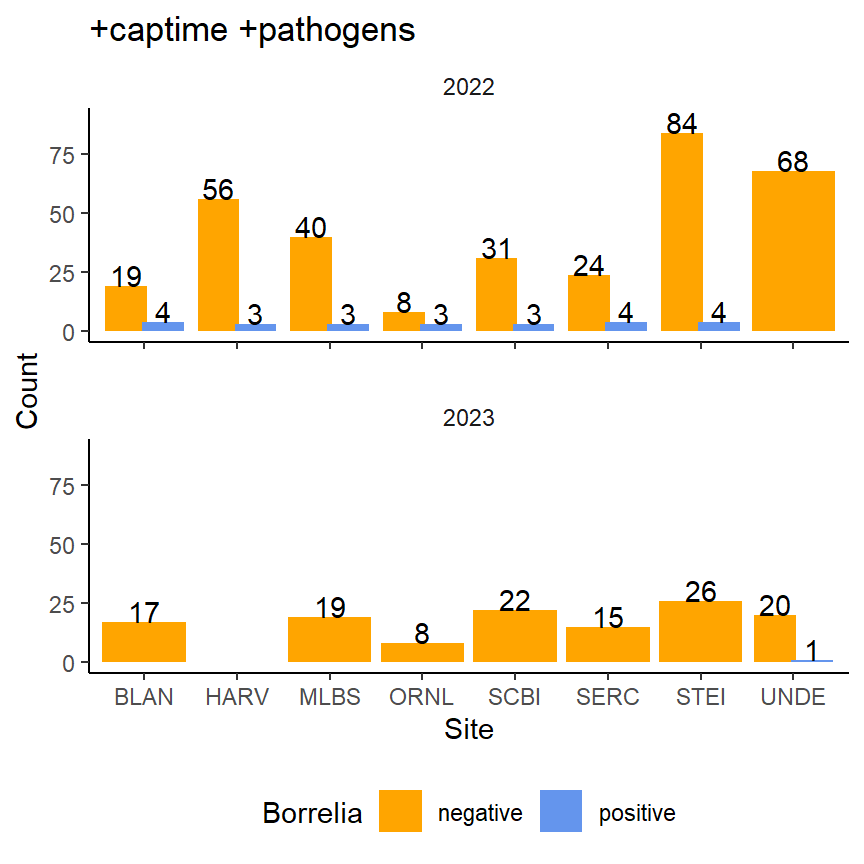

```r
tmp <- full_data |>
  mutate(
    Bb_missing = is.na(B_burgdorferi),
    captime_missing = if_else(is.na(cap_prop_night), "no captime", "captime"),
    B_burgdorferi = case_when(
      is.na(B_burgdorferi) ~ "not sampled",
      B_burgdorferi == TRUE ~ "positive",
      B_burgdorferi == FALSE ~ "negative"
    )
  ) |>
  group_by(year, siteID, captime_missing, B_burgdorferi) |> tally()

pd = position_dodge(0.8)

theme_set(theme_classic())

tmp |>
  filter(year %in% 2022:2024, B_burgdorferi != "not sampled", captime_missing == "captime") |>
  ggplot(aes(x = siteID, y = n, fill = B_burgdorferi)) +
  facet_rep_wrap(~year, ncol = 1) +
  geom_col(position = pd) +
  theme(legend.position = "bottom", strip.background = element_blank()) +
  labs(x = "Site", y = "Count", title = "+captime +pathogens", fill = "Borrelia") +
  geom_text(aes(label = n), position = pd, vjust = 0) +
  scale_y_continuous(limits = c(0, 90)) +
  scale_fill_manual(values = c("orange", "cornflowerblue"))
```

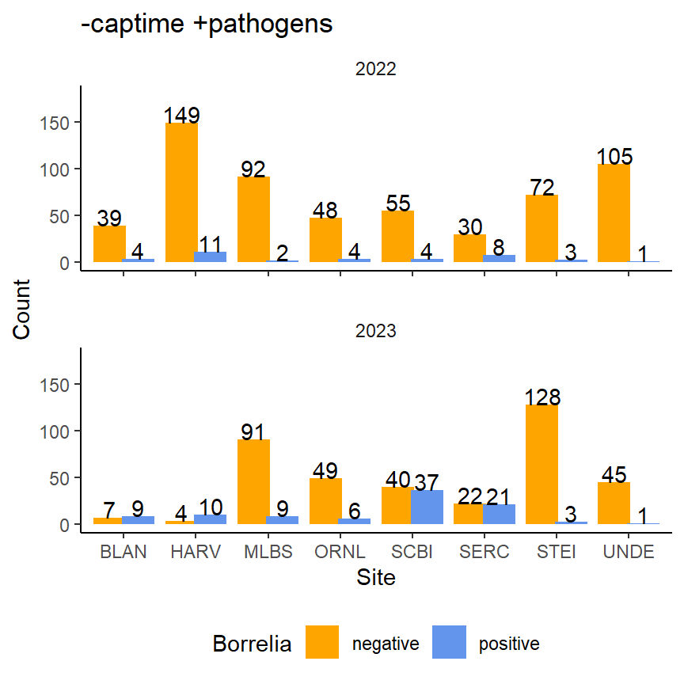

```r
ggsave("cap_path_counts.jpg", width = 4.5, height = 4.5)

tmp |>
  filter(year %in% 2022:2024, B_burgdorferi != "not sampled", captime_missing != "captime") |>
  ggplot(aes(x = siteID, y = n, fill = B_burgdorferi)) +
  facet_rep_wrap(~year, ncol = 1) +
  geom_col(position = pd) +
  theme(legend.position = "bottom", strip.background = element_blank()) +
  labs(x = "Site", y = "Count", title = "-captime +pathogens", fill = "Borrelia") +
  geom_text(aes(label = n), position = pd, vjust = 0) +
  scale_y_continuous(limits = c(0, 180)) +
  scale_fill_manual(values = c("orange", "cornflowerblue"))
```

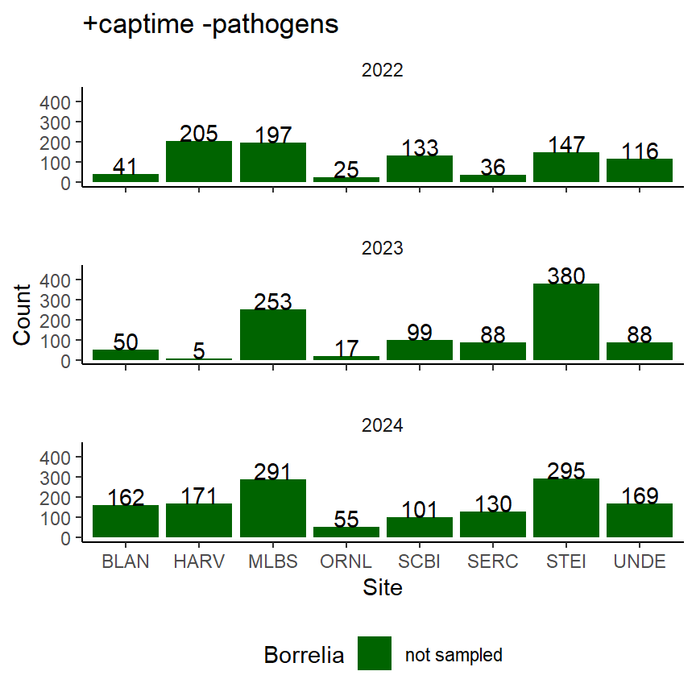

```r
ggsave("nocap_path_counts.jpg", width = 4.5, height = 4.5)

tmp |>
  filter(year %in% 2022:2024, B_burgdorferi == "not sampled", captime_missing == "captime") |>
  ggplot(aes(x = siteID, y = n, fill = B_burgdorferi)) +
  facet_rep_wrap(~year, ncol = 1) +
  geom_col(position = pd) +
  theme(legend.position = "bottom", strip.background = element_blank()) +
  labs(x = "Site", y = "Count", title = "+captime -pathogens", fill = "Borrelia") +
  geom_text(aes(label = n), position = pd, vjust = 0) +
  scale_y_continuous(limits = c(0, 450)) +
  scale_fill_manual(values = "darkgreen")
```

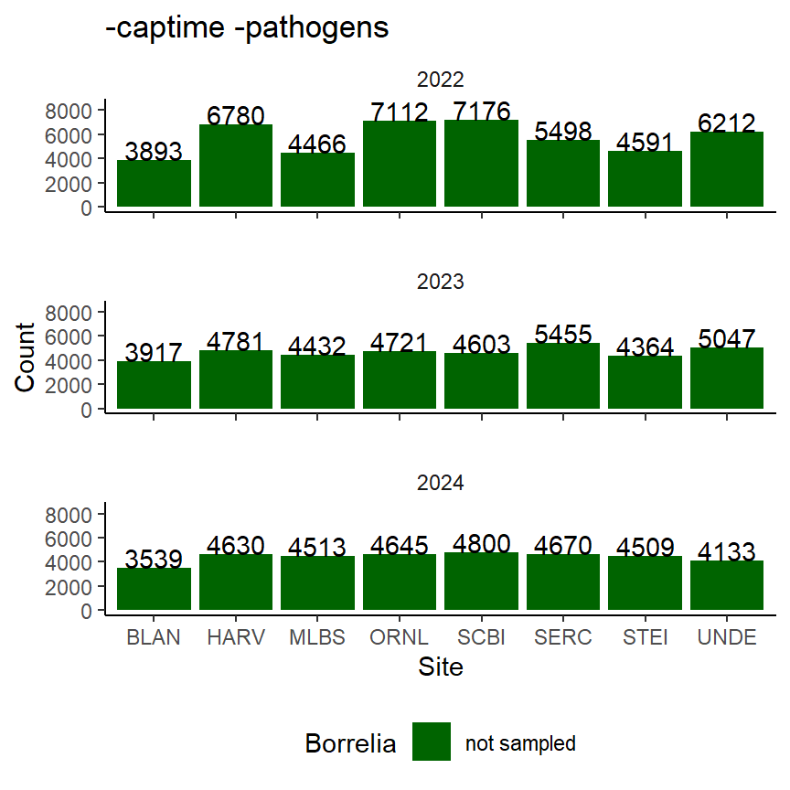

```r
ggsave("cap_nopath_counts.jpg", width = 4.5, height = 4.5)

tmp |>
  filter(year %in% 2022:2024, B_burgdorferi == "not sampled", captime_missing != "captime") |>
  ggplot(aes(x = siteID, y = n, fill = B_burgdorferi)) +
  facet_rep_wrap(~year, ncol = 1) +
  geom_col(position = pd) +
  theme(legend.position = "bottom", strip.background = element_blank()) +
  labs(x = "Site", y = "Count", title = "-captime -pathogens", fill = "Borrelia") +
  geom_text(aes(label = n), position = pd, vjust = 0) +
  scale_y_continuous(limits = c(0, 8500)) +
  scale_fill_manual(values = "darkgreen")
```

```r
ggsave("nocap_nopath_counts.jpg", width = 4.5, height = 4.5)
```

```r
full_data |> filter(year %in% 2022) |>
  mutate(
    Bb_missing = is.na(B_burgdorferi),
    captime_missing = is.na(cap_prop_night),
    state = case_when(
      !captime_missing & !Bb_missing ~ "timing_pathogens",
      !captime_missing & Bb_missing ~ "timing_noPathogens",
      captime_missing & !Bb_missing ~ "noTiming_pathogens",
      captime_missing & Bb_missing ~ "noTiming_noPathogens"
    )
  ) |>
  group_by(year, siteID, state) |>
  tally() |>
  arrange(state) |>
  pivot_wider(names_from = state, values_from = n) |>
  write.csv(file = "state_table_2022.csv", row.names = FALSE)

full_data |> filter(year %in% 2023) |>
  mutate(
    Bb_missing = is.na(B_burgdorferi),
    captime_missing = is.na(cap_prop_night),
    state = case_when(
      !captime_missing & !Bb_missing ~ "timing_pathogens",
      !captime_missing & Bb_missing ~ "timing_noPathogens",
      captime_missing & !Bb_missing ~ "noTiming_pathogens",
      captime_missing & Bb_missing ~ "noTiming_noPathogens"
    )
  ) |>
  group_by(year, siteID, state) |>
  tally() |>
  arrange(state) |>
  pivot_wider(names_from = state, values_from = n)|>
  write.csv(file = "state_table_2023.csv", row.names = FALSE)
```

# 6 Weather

# 7 Ticks

```r
# read in tick object
tick_obj <- readRDS(
  file.path(neon_data_dir, "tick-drag-cloth-sampling.rds")
)

# Get the tick table
ticks <- tick_obj$tck_taxonomyProcessed |> tibble() |>
  mutate(
    year = year(collectDate), month = month(collectDate),
    date = date(collectDate), week = week(collectDate),
    siteID = gsub("(.*)_.*", "\\1", plotID)
  ) |>
  group_by(siteID, plotID, year, month, sexOrAge) |>
  mutate(total_tickgrp_count = sum(individualCount)) |>
  group_by(siteID, plotID, year, month) |>
  arrange(siteID, plotID, year, month, collectDate) |>
  mutate(
    tck_samp_interval = interval(first(date), last(date)),
    tck_samp_days = time_length(tck_samp_interval, "days") + 1
  ) |>
  ungroup() |>
  mutate(
    tck_density = individualCount / tck_samp_days
  )

# Get the variable lookup table
tick_vars <- tick_obj$variables_10093 |> tibble() |>
  filter(table == "tck_taxonomyProcessed") |>
  select(fieldName, units, description)
```

```r
# total ticks by site by year (all species)
ticks |>
  filter(year %in% 2021:2024) |>
  select(
    siteID, plotID, year, month, sexOrAge, genus, scientificName,
    individualCount
  ) |>
  group_by(year, siteID) |>
  summarise(n_ticks = sum(individualCount, na.rm = TRUE), .groups = "keep") |>
  pivot_wider(names_from = year, values_from = n_ticks) |>
  mutate(total = rowSums(across(`2021`:`2024`))) |>
  arrange(desc(total))
```

```
## # A tibble: 8 × 6
## # Groups:   siteID [8]
##   siteID `2021` `2022` `2023` `2024` total
##   <chr>   <dbl>  <dbl>  <dbl>  <dbl> <dbl>
## 1 ORNL     7170   6424   3678   2483 19755
## 2 SCBI     2811   1276   3688   5026 12801
## 3 SERC     3437   1698   4777   1261 11173
## 4 BLAN     3871    585   2720   1371  8547
## 5 HARV      258    780   3734   2162  6934
## 6 STEI       21    355     54    179   609
## 7 MLBS       47     26     64     54   191
## 8 UNDE        8     44      5     29    86
```

```r
# get monthly plot densities of Ixodes (or larval) ticks from 2021 - 2024 for each group
ixodes <- ticks |>
  filter(sexOrAge == "Larva" | genus == "Ixodes", year %in% 2021:2024) |>
  group_by(siteID, plotID, year, month, sexOrAge) |>
  mutate(
    count = sum(individualCount),
    ixodes_prop = if_else(
      sexOrAge == "Larva", NA, count/total_tickgrp_count
    )
  ) |>
  select(
    siteID, plotID, year, month, sexOrAge, tck_samp_interval,
    tck_samp_days, count, total_tickgrp_count, ixodes_prop
  ) |>
  distinct() |>
  ungroup(sexOrAge) |>
  mutate(
    # density = count / tck_samp_days,
    # # trying to estimate larval tick ixodes props.
    mean_ixodes_prop = mean(ixodes_prop, na.rm = TRUE),
  ) |>
  rowwise() |>
  mutate(
    count = round(total_tickgrp_count * mean_ixodes_prop),
    # count = if_else(
    #   sexOrAge == "Larva",
    #   round(count * mean_ixodes_prop),
    #   round(total_tickgrp_count * mean_ixodes_prop)
    # ),
    density = count / tck_samp_days
  ) |>
  ungroup()

tick_table <- ixodes |>
  pivot_wider(
    names_from = sexOrAge, values_from = c(count, density)
  ) |>
  mutate(
    across(count_Larva:density_Female, ~replace_na(.x, 0)), # NA actually 0
    count_Ixodes = rowSums(across(contains("count_"))),
    density_Ixodes = count_Ixodes / tck_samp_days,
    count_Adult = count_Male + count_Female,
    density_Adult = count_Adult / tck_samp_days,
    count_AllTicks = total_tickgrp_count,
    density_AllTicks = total_tickgrp_count / tck_samp_days
  ) |>
  relocate(c(count_Adult, count_Ixodes), .after = count_Female) |>
  relocate(c(density_Adult, density_Ixodes), .after = density_Female) |>
  select(-total_tickgrp_count)

# Total counts
tick_table |>
  group_by(year) |>
  summarize(across(contains("count"), ~sum(.x, na.rm = TRUE)))
```

```
## # A tibble: 4 × 8
##    year count_Larva count_Male count_Nymph count_Female count_Adult count_Ixodes
##   <dbl>       <dbl>      <dbl>       <dbl>        <dbl>       <dbl>        <dbl>
## 1  2021        5417         12         348           12          24         5789
## 2  2022        1065         14         233            8          22         1320
## 3  2023        4921         13         450            7          20         5391
## 4  2024        3484         11         407           13          24         3915
## # ℹ 1 more variable: count_AllTicks <dbl>
```

```r
# Total densities
tick_table |>
  group_by(year) |>
  summarize(across(contains("density"), ~mean(.x, na.rm = TRUE)))
```

```
## # A tibble: 4 × 8
##    year density_Larva density_Male density_Nymph density_Female density_Adult
##   <dbl>         <dbl>        <dbl>         <dbl>          <dbl>         <dbl>
## 1  2021          7.52       0.0558         1.18          0.0512        0.107
## 2  2022          4.32       0.0673         0.543         0.0393        0.107
## 3  2023          7.14       0.0508         1.01          0.0123        0.0632
## 4  2024          5.73       0.0404         0.811         0.0368        0.0772
## # ℹ 2 more variables: density_Ixodes <dbl>, density_AllTicks <dbl>
```

```r
## NOTE These larvae are from ALL ticks. Should I assume the proportion of Ixodes
## adults is comparable to the proportion of ixodes larvae?
```

## 7.1 Tick pathogens

```r
tick_pathogen_obj <- readRDS(
  file.path(neon_data_dir, "tick-pathogen-status.rds")
)

tick_pathogens <- tick_pathogen_obj$tck_pathogen |> tibble() |>
  mutate(year = year(collectDate), month = month(collectDate))

# get only B.b. results from 2021-2024
borrelia <- tick_pathogens |>
  filter(
    grepl("burgdorferi", testPathogenName),
    year %in% 2021:2024
  ) |> select(
    year, month, collectDate, plotID, individualCount, testResult
  )

# calculate some basic values
borrelia <- borrelia |> group_by(year, month, plotID) |>
  mutate(
    n_testticks_plotmonth = sum(individualCount, na.rm = TRUE),
    n_Bbpos_plotmonth = sum(testResult == "Positive", na.rm = TRUE),
    Bb_tickrate_plotmonth = n_Bbpos_plotmonth / n_testticks_plotmonth
  ) |>
  group_by(year) |>
  mutate(
    n_testticks_plotyear = sum(individualCount, na.rm = TRUE),
    n_Bbpos_plotyear = sum(testResult == "Positive", na.rm = TRUE),
    Bb_tickrate_plotyear = n_Bbpos_plotyear / n_testticks_plotyear
  ) |>
  ungroup()

# join the new Borrelia tick columns into the
full_data <- left_join(
  full_data,
  borrelia |>
    select(year, month, plotID, n_testticks_plotmonth:Bb_tickrate_plotyear) |>
    distinct(),
  by = c("plotID", "year", "month")
)

# check the merge
stopifnot(nrow(full_data) == n_mammals)
```

# 8 Genetics (resistance)

# 9 Plant communities

```r
tree_prods <- readRDS(
  file.path(neon_data_dir, "litterfall-data.rds")
)
```

# 10 Litterfall

```r
litter_prod <- readRDS(
  file.path(neon_data_dir, "litterfall-data.rds")
)

names(litter_prod)
```

```
##  [1] "categoricalCodes_10033"      "citation_10033_PROVISIONAL"
##  [3] "citation_10033_RELEASE-2025" "issueLog_10033"
##  [5] "ltr_chemistrySubsampling"    "ltr_fielddata"
##  [7] "ltr_litterCarbonNitrogen"    "ltr_litterLignin"
##  [9] "ltr_massdata"                "ltr_pertrap"
## [11] "readme_10033"                "validation_10033"
## [13] "variables_10033"
```

```r
litter_lookup <- litter_prod$variables_10033 |> tibble()

litter_lookup |>
  filter(table == "ltr_massdata") |>
  select(fieldName, description)
```

```
## # A tibble: 24 × 2
##    fieldName     description
##    <chr>         <chr>
##  1 uid           Unique ID within NEON database; an identifier for the record
##  2 namedLocation Name of the measurement location in the NEON database
##  3 domainID      Unique identifier of the NEON domain
##  4 siteID        NEON site code
##  5 plotID        Plot identifier (NEON site code_XXX)
##  6 trapID        Identifier for trap
##  7 weighDate     Date that sample or subsample was weighed
##  8 setDate       Date that trap was set
##  9 collectDate   Date of the collection event
## 10 eventID       An identifier for the set of information associated with the e…
## # ℹ 14 more rows
```

```r
litter_loc_path = "data/litter-trap-locations.rds"
if (!file.exists(litter_loc_path)) {
  litter_locations <- litter_prod$ltr_pertrap |>
    select(
      trapID, namedLocation, decimalLatitude, decimalLongitude, elevation
    ) |>
    geoNEON::getLocByName(token = my_token) |>
    mutate(elevation = as.numeric(elevation))
  saveRDS(litter_locations, litter_loc_path)
} else {litter_locations <- readRDS(litter_loc_path)}

litter <- litter_prod$ltr_massdata |>
  tibble() |>
  left_join(litter_locations) |>
  mutate(
    year = year(collectDate), month = month(collectDate),
    trapping_days = time_length(collectDate - setDate, "days"),
    mass_per_trapdays = dryMass / trapping_days
  )
```

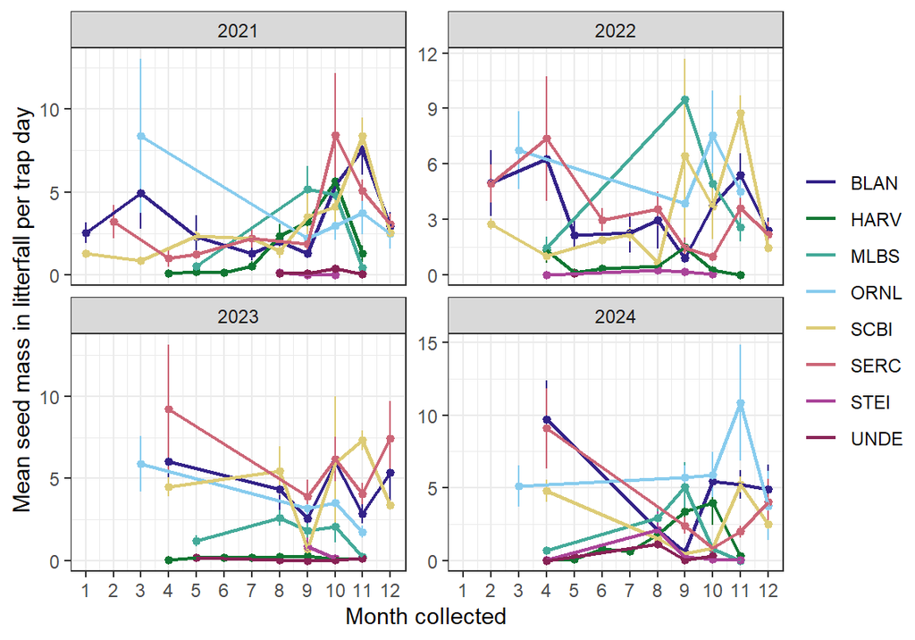

```r
# plot average monthly seed mass across years
litter |>
  filter(functionalGroup == "Seeds", year %in% 2021:2024) |>
  ggplot(aes(x = month, y = dryMass, col = siteID)) +
  facet_wrap(~year, scales = "free_y") +
  stat_summary(fun.data = mean_se, size = 0.25, show.legend = FALSE) +
  stat_summary(fun = mean, geom = "line", linewidth = 0.75) +
  labs(
    y = "Mean seed mass in litterfall per trap day",
    x = "Month collected",
    col = NULL
  ) +
  scale_color_manual(values = NEON_sites$color_hex) +
  theme_bw() +
  theme(legend.margin = margin(l = -2)) +
  scale_x_continuous(breaks = 1:12)
```

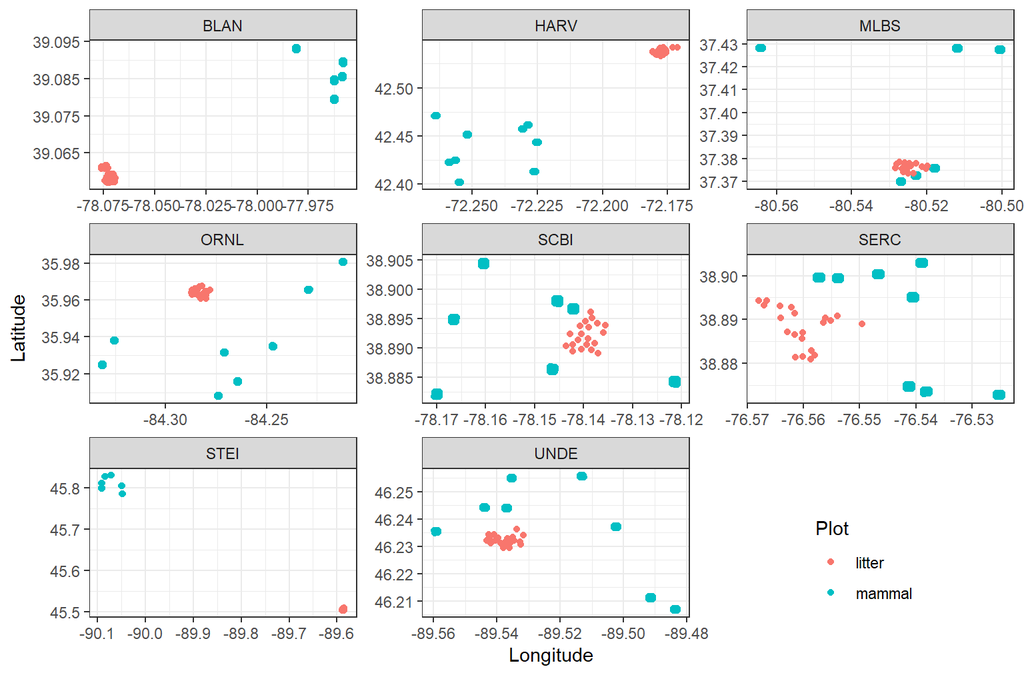

```r
ggsave(
  file.path("graphics", "siteMonthlySeedMass_2021-2024.jpg"),
  width = 6, height = 0.7*6
)
ggplot() +
  facet_wrap(~siteID, scales = "free") +
  geom_point(
    data = trap_locations,
    aes(x = adjDecimalLongitude, y = adjDecimalLatitude, col = "mammal")
  ) +
  geom_point(
    data = litter_locations,
    aes(x = decimalLongitude, y = decimalLatitude, col = "litter")
  ) +
  theme_bw() +
  theme(
    legend.position = "inside", legend.position.inside = c(0.9, 0),
    legend.justification = c(1, 0),
    # axis.text = element_blank()
  ) +
  labs(x = "Longitude", y = "Latitude", col = "Plot") #+
```

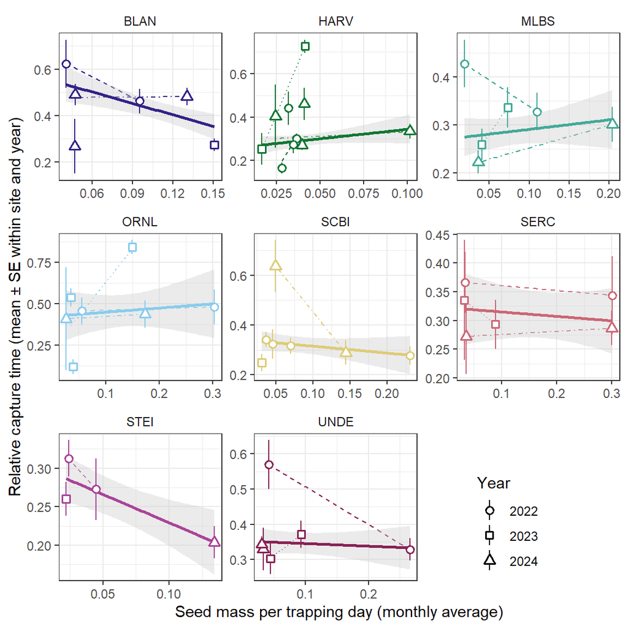

```r
# scale_x_continuous(
#   breaks = seq(-100, -50, by = 0.1),
#   minor_breaks = seq(-100, -50, by = 0.05)
# )

ggsave(
  file.path("graphics", "litterfall-mammal-trap-proximity.jpg"),
  width = 8, height = 0.66*8
)
# summarize the seed mass by site, plot, year, and month and add it to full data
full_data <- litter |>
  group_by(siteID, year, month) |>
  mutate(
    nSeedSamples_siteMean = n(),
    seedMass_perTrapDays_siteMean = mean(mass_per_trapdays, na.rm = TRUE),
    seedTrapDays_siteMean = mean(trapping_days, na.rm = TRUE)
  ) |>
  # group_by(plotID, .add = TRUE) |>
  # mutate(
  #   seedMass_perTrapDays_plotMean = mean(mass_per_trapdays, na.rm = TRUE),
  #   seedTrapDays_plotMean = mean(trapping_days, na.rm = TRUE)
  # ) |>
  group_by(siteID, year, .add = FALSE) |>
  mutate(
    nSeedSamples_siteMeanYear = n(),
    seedMass_perTrapDays_siteMeanYear = mean(mass_per_trapdays, na.rm = TRUE),
    seedTrapDays_siteMeanYear = mean(trapping_days, na.rm = TRUE)
  ) |>
  # group_by(plotID, .add = TRUE) |>
  # mutate(
  #   seedMass_perTrapDays_plotMeanYear = mean(mass_per_trapdays, na.rm = TRUE),
  #   seedTrapDays_plotMeanYear = mean(trapping_days, na.rm = TRUE)
  # ) |>
  select(
    siteID, year, month,
    seedMass_perTrapDays_siteMean, seedTrapDays_siteMean,
    seedMass_perTrapDays_siteMeanYear, seedTrapDays_siteMeanYear,
    nSeedSamples_siteMean, nSeedSamples_siteMeanYear
  ) |>
  distinct() |>
  right_join(full_data)
full_data |>
  filter(!is.na(cap_prop_night), !is.na(seedMass_perTrapDays_siteMean)) |>
  ggplot(
    aes(
      x = seedMass_perTrapDays_siteMean, y = cap_prop_night, col = siteID
    )
  ) +
  facet_wrap(~siteID, scales = "free") +
  geom_smooth(
    method = "lm", formula = "y ~ x", se = FALSE, #show.legend = FALSE,
    size = 0.5, # linetype = "dashed",
    aes(group = interaction(siteID, year), linetype = factor(year))
  ) +
  geom_smooth(
    method = "lm", formula = "y ~ x", fill = "grey80", size = 1,
    #show.legend = FALSE,
    aes(group = siteID)
  ) +
  stat_summary(
    fun.data = mean_se, fill = "white", # size = 0.4, # show.legend = FALSE,
    aes(group = interaction(siteID, year, month), shape = factor(year))
  ) +
  # geom_smooth(method = "lm", aes(group = 1), col = "black") +
  labs(
    x = "Seed mass per trapping day (monthly average)",
    y = "Relative capture time (mean ± SE within site and year)"
  ) +
  scale_color_manual(guide = "none", values = NEON_sites$color_hex) +
  scale_shape_manual(
    name = "Year", labels = c(2022:2024), values = c(21, 22, 24)
  ) +
  scale_linetype_manual(name = "Year", values = c(2:4), guide = FALSE) +
  theme_bw() +
  theme(
    legend.position.inside = c(4/5, 0), legend.position = "inside",
    legend.justification = c(0.5, 0),
    strip.background = element_blank()
  )
```

```r
ggsave(
  file.path("graphics", "captureTime-vs-seedMass.jpg"),
  width = 6, height = 6, dpi = 300
)
```

```r
pd = position_dodge(0.8)

tmp <- full_data |>
  filter(!is.na(cap_prop_night)) |>
  group_by(siteID, year) |> arrange(year, month) |>
  summarize(first_month = first(month), last_month = last(month))
```

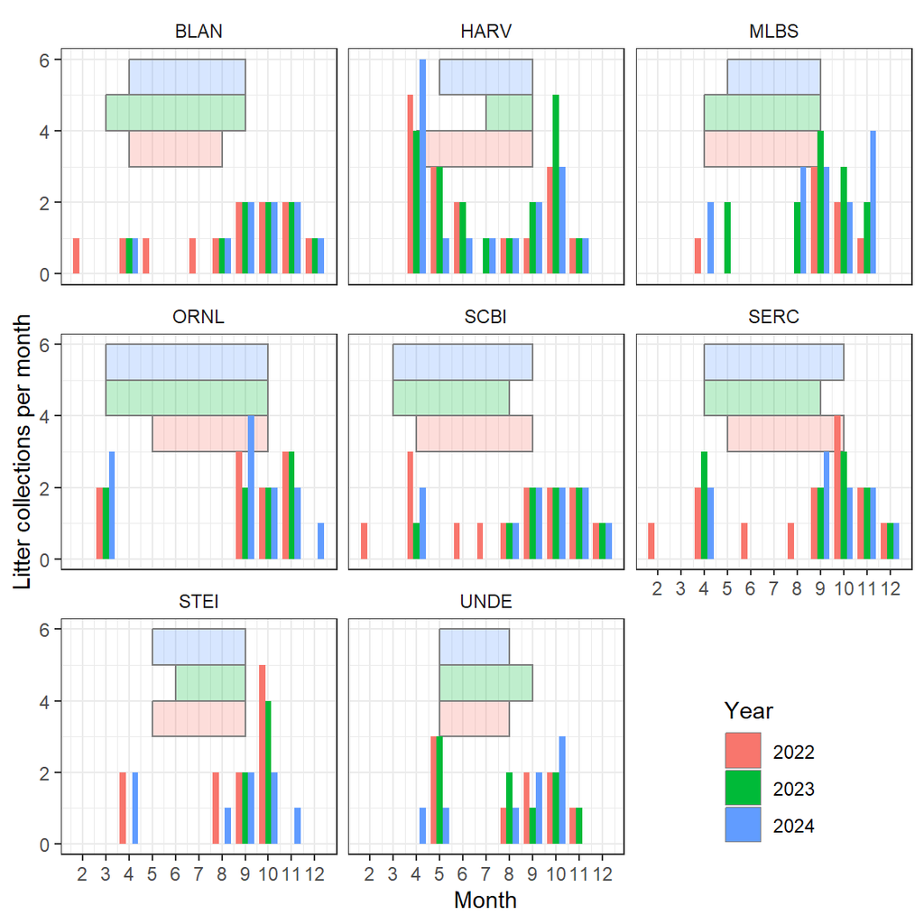

```r
litter |>
  filter(year %in% 2022:2024) |>
  group_by(siteID, year, month) |>
  summarize(n = length(unique(collectDate)), .groups = "drop") |>
  complete(siteID, year, month) |>
  mutate(n = replace_na(n, 0)) |>
  ggplot(aes(x = month, y = n, fill = factor(year))) +
  geom_rect(
    data = tmp, inherit.aes = FALSE, alpha = 0.25, col = "grey50",
    aes(
      xmin = first_month, xmax = last_month,
      ymin = year - 2019, ymax = year - 2018,
      fill = factor(year)
    )
  ) +
  # geom_line(aes(col = factor(year)), position = pd, linetype = "dotted") +
  geom_col(position = pd, alpha = 1, width = 0.8) +
  # geom_point(aes(col = factor(year)), position = pd) +
  facet_wrap(~siteID) +
  scale_x_continuous(breaks = 1:12) +
  labs(
    y = "Litter collections per month", x = "Month", fill = "Year", color = "Year"
  ) +
  theme_bw() +
  theme(
    legend.position.inside = c(0.9, 0), legend.position = "inside",
    legend.justification = c(1, 0),
    strip.background = element_blank()
  )
```

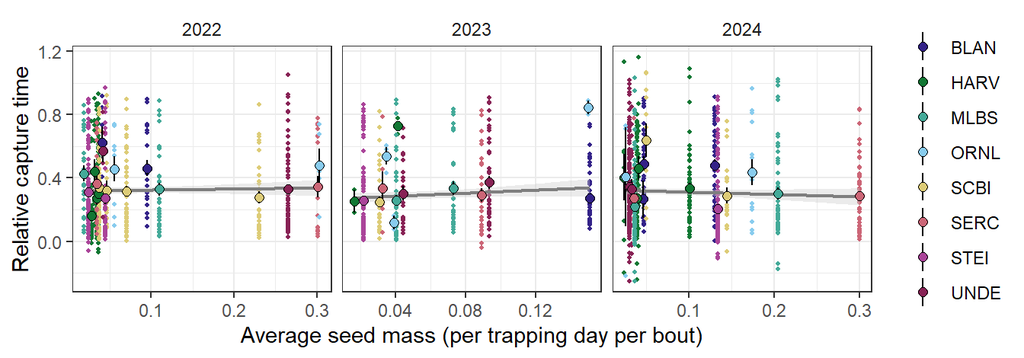

```r
ggsave(
  file.path("graphics", "monthly-litter-captures_with-capture-time-windows.jpg")
)
full_data |>
  filter(!is.na(cap_prop_night), !is.na(seedMass_perTrapDays_siteMean)) |>
  ggplot(
    aes(
      x = seedMass_perTrapDays_siteMean, y = cap_prop_night
    )
  ) +
  facet_wrap(~year, scales = "free_x", ncol = 3) +
  geom_point(
    shape = 16, size = 0.75, #col = "grey50"
    aes(col = siteID)
  ) +
  geom_smooth(
    method = "lm", formula = "y ~ x", aes(group = 1), col = "grey50",
    fill = "grey80", linewidth = 0.75
  ) +
  stat_summary(
    fun.data = mean_se, shape = 21, size = 0.5, alpha = 1, stroke = 0.5,
    linewidth = 0.5,
    aes(fill = siteID)
  ) +
  theme_bw() +
  theme(strip.background = element_blank()) +
  scale_fill_manual(values = NEON_sites$color_hex) +
  scale_color_manual(values = NEON_sites$color_hex, guide = FALSE) +
  labs(
    fill = NULL, x = "Average seed mass (per trapping day per bout)",
    y = "Relative capture time"
  )
```

```r
ggsave(
  file.path(
    "graphics", "Capture-time-by-seedmass_within-year.jpg"
  ),
  width = 7, height = 0.35*7, dpi = 300
)
```

# 11 Beetles

# 12 Updated *Borrelia* infection status (USF)

# 13 Distances

```r
location_dir = file.path(neon_data_dir, "location_data")

plot_locs <- readRDS(
  file.path(location_dir, "plot-centroid-locations.rds")
) |> tibble()

plot_locs |>
  select(
    siteID, plotID, decimalLatitude, decimalLongitude, elevation,
    xOffset, yOffset, zOffset
  )
```

```
## # A tibble: 57 × 8
##    siteID plotID   decimalLatitude decimalLongitude elevation xOffset yOffset
##    <chr>  <chr>              <dbl>            <dbl>     <dbl>   <dbl>   <dbl>
##  1 HARV   HARV_016            42.5            -72.2      220.       0       0
##  2 HARV   HARV_032            42.5            -72.2      241.       0       0
##  3 HARV   HARV_021            42.5            -72.3      177.       0       0
##  4 HARV   HARV_008            42.4            -72.2      241.       0       0
##  5 HARV   HARV_006            42.4            -72.3      186.       0       0
##  6 HARV   HARV_023            42.4            -72.2      174.       0       0
##  7 HARV   HARV_001            42.4            -72.3      201.       0       0
##  8 HARV   HARV_014            42.5            -72.3      207.       0       0
##  9 HARV   HARV_010            42.4            -72.3      197.       0       0
## 10 BLAN   BLAN_003            39.1            -78.0      121.       0       0
## # ℹ 47 more rows
## # ℹ 1 more variable: zOffset <dbl>
```

```r
# use BLAN as an example to get distances among plots
BLAN_dists <- plot_locs |>
  filter(siteID == "BLAN") |>
  select(decimalLongitude, decimalLatitude) |>
  geosphere::distm()

colnames(BLAN_dists) <- plot_locs |> filter(siteID == "BLAN") |> pull(plotID)
rownames(BLAN_dists) <- plot_locs |> filter(siteID == "BLAN") |> pull(plotID)

BLAN_dists
```

```
##           BLAN_003  BLAN_001  BLAN_009 BLAN_002  BLAN_006
## BLAN_003    0.0000 1168.4699  757.1836 2196.228  568.7061
## BLAN_001 1168.4699    0.0000  434.4510 2004.005  649.3503
## BLAN_009  757.1836  434.4510    0.0000 2109.865  351.1593
## BLAN_002 2196.2276 2004.0045 2109.8648    0.000 1858.9791
## BLAN_006  568.7061  649.3503  351.1593 1858.979    0.0000
```

```r
max(BLAN_dists) # 2.2 km
```

```
## [1] 2196.228
```

```r
min(BLAN_dists[lower.tri(BLAN_dists)]) # 0.4 km
```

```
## [1] 351.1593
```

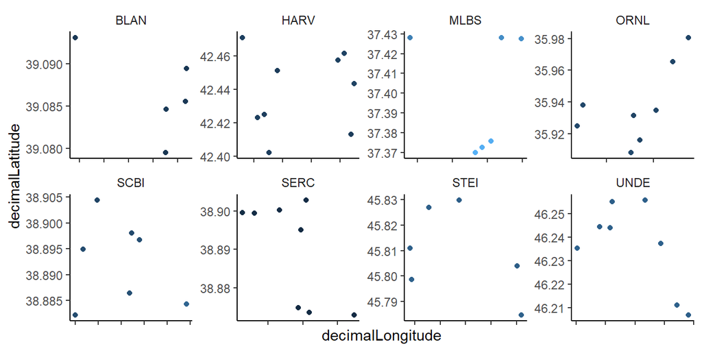

```r
# look at the plot distribution within sites
plot_locs |>
  ggplot(aes(x = decimalLongitude, y = decimalLatitude, col = elevation)) +
  geom_point() +
  facet_wrap(~siteID, scales = "free", ncol = 4) +
  theme(
    legend.position = "none", strip.background = element_blank(),
    axis.text.x = element_blank()
  )
```

# 14 Summary variables

```r
# estimate population size and
full_data <- full_data |>
  group_by(year, taxonID, plotID) |>
  mutate(
    year_popsize = n(),
    Bb_mouserate_yr = sum(B_burgdorferi, na.rm = TRUE) / year_popsize
  ) |>
  group_by(year, month, plotID) |>
  mutate(
    month_popsize = n(),
    Bb_mouserate_mnth = sum(B_burgdorferi, na.rm = TRUE) / month_popsize
  )
```

# 15 Preliminary infection modeling

This should probably be in a new file…

```r
names(full_data)
```

```
##  [1] "siteID"                            "year"
##  [3] "month"                             "seedMass_perTrapDays_siteMean"
##  [5] "seedTrapDays_siteMean"             "seedMass_perTrapDays_siteMeanYear"
##  [7] "seedTrapDays_siteMeanYear"         "nSeedSamples_siteMean"
##  [9] "nSeedSamples_siteMeanYear"         "cap_id_num"
## [11] "uid"                               "nightuid"
## [13] "plotID"                            "trapCoordinate"
## [15] "decimalLatitude"                   "decimalLongitude"
## [17] "elevation"                         "trapStatus"
## [19] "day"                               "DOY"
## [21] "collectDate"                       "endDate"
## [23] "tagID"                             "taxonID"
## [25] "scientificName"                    "sex"
## [27] "recapture"                         "fate"
## [29] "lifeStage"                         "testes"
```

[output cut: 28 more lines]

```r
glm.Bb <- glm(
  B_burgdorferi ~ weight + sex +
    # decimalLatitude + decimalLongitude + # not affected by lat, long
    # taxonID + # not affected by species (among Peromyscus)
    # larvalTicksAttached + nymphalTicksAttached +
    # tickNumber +
    # (as.numeric(tickNumber) > 2) + # more than 1-5 ticks
    # month_popsize +
    # Bb_mouserate_mnthformula +
    year_popsize +
    Bb_mouserate_yr +
    year_popsize:Bb_mouserate_yr +
    # Bb_tickrate_plotmonth +
    # Bb_tickrate_plotyear +
    year +
    month, # + # + hindfootLength + DOY + month + year,
  # DOY,
  data = full_data |>
    filter(taxonID %in% c("PELE", "PEMA", "PELEPEMA"), sex != "U"),
  family = "binomial"
)

# model results
summary(glm.Bb)
```

```
##
## Call:
## glm(formula = B_burgdorferi ~ weight + sex + year_popsize + Bb_mouserate_yr +
##     year_popsize:Bb_mouserate_yr + year + month, family = "binomial",
##     data = filter(full_data, taxonID %in% c("PELE", "PEMA", "PELEPEMA"),
##         sex != "U"))
##
## Coefficients:
##                                Estimate Std. Error z value Pr(>|z|)
## (Intercept)                  711.877677 174.719441   4.074 4.61e-05 ***
## weight                         0.051712   0.020379   2.537   0.0112 *
## sexM                           0.404737   0.165727   2.442   0.0146 *
## year_popsize                  -0.003845   0.001773  -2.169   0.0301 *
## Bb_mouserate_yr                9.617581   1.363804   7.052 1.76e-12 ***
## year                          -0.353975   0.086401  -4.097 4.19e-05 ***
## month                         -0.055598   0.053270  -1.044   0.2966
## year_popsize:Bb_mouserate_yr   0.190577   0.031401   6.069 1.29e-09 ***
## ---
## Signif. codes:  0 '***' 0.001 '**' 0.01 '*' 0.05 '.' 0.1 ' ' 1
##
## (Dispersion parameter for binomial family taken to be 1)
##
##     Null deviance: 1423.7  on 1821  degrees of freedom
## Residual deviance: 1089.3  on 1814  degrees of freedom
##   (31580 observations deleted due to missingness)
## AIC: 1105.3
##
## Number of Fisher Scoring iterations: 6
```

```r
# sample size of fit
glm.Bb$model |> nrow()
```

```
## [1] 1822
```

```r
# which columns are the limitting factors (most NAs)?
glm.Bb$data[, names(glm.Bb$model)] |>
  filter(year %in% 2021:2024) |>
  summary()
```

```
##  B_burgdorferi       weight          sex             year_popsize
##  Mode :logical   Min.   : 6.00   Length:12403       Min.   :  1.0
##  FALSE:1840      1st Qu.:17.00   Class :character   1st Qu.: 53.0
##  TRUE :229       Median :20.00   Mode  :character   Median : 99.0
##  NA's :10334     Mean   :20.42                      Mean   :123.7
##                  3rd Qu.:24.00                      3rd Qu.:176.0
##                  Max.   :43.00                      Max.   :304.0
##                  NA's   :2937
##  Bb_mouserate_yr        year          month
##  Min.   :0.00000   Min.   :2021   Min.   : 3.000
##  1st Qu.:0.00000   1st Qu.:2021   1st Qu.: 6.000
##  Median :0.00000   Median :2023   Median : 8.000
##  Mean   :0.01805   Mean   :2023   Mean   : 7.285
##  3rd Qu.:0.01685   3rd Qu.:2024   3rd Qu.: 8.000
##  Max.   :1.00000   Max.   :2024   Max.   :11.000
##
```

```r
# which plots are not represented in the tick pathogen data?
tibble(
  plotID = unique(full_data$plotID),
  in_borrelia_dat = plotID %in% borrelia$plotID
)
```

```
## # A tibble: 57 × 2
##    plotID   in_borrelia_dat
##    <chr>    <lgl>
##  1 HARV_008 FALSE
##  2 HARV_021 FALSE
##  3 HARV_023 FALSE
##  4 HARV_006 TRUE
##  5 HARV_014 FALSE
##  6 HARV_032 FALSE
##  7 HARV_001 TRUE
##  8 HARV_010 FALSE
##  9 BLAN_001 FALSE
## 10 BLAN_003 FALSE
## # ℹ 47 more rows
```

The above model still needs: * [ ] weather (temp and precip) * [x] *Borrelia* prevelance (tick and mice populations) * [ ] genetic resistance * [ ] population density * [ ] movement